# Hamiltonian Monte Carlo and DSGE

# The results

All the program is implemented in Julia, a relatively new programming language focused on scientific programming. We wrote almost everything from the ground up, except the HMC sampler[^3]. HMC samplers come in different flavours and we use No U Turn Sampler (NUTS), by Gelman et al. (2014). This allows us to control every single aspect of the program. Everything is implemented in pure Julia. We will show the result from the estimation bellow. We use 1000 samples for burn in and 2000 samples to generate the graphics bellow. The model is the model from Galí (2009), and we provide a handy table for the parameter:

| Letter | Structural Parameter | Value |
| --- | --- | --- |
| $\beta$ | Discount Factor | 0.99 |
| $\epsilon$ | Elasticity of the varieties | 6 |
| $\theta$ | Probability of the firm keep the price fixed | 2/3 |
| $\sigma$ | CRRA Parameter for consumption | 1 |
| $\phi$ | CRRA Parameter for work | 1 |
| $\sigma_v$ | Variance of the monetary policy shock | 1 |
| $\phi_\pi$ | Central Bank’s inflation reaction parameter | 1.5 |
| $\phi_y$ | Central Bank’s product reaction parameter | 0.5/4 |
| $\rho$ | Monetary Policy Shock Autoregressive parameter | 0.5 |

We also have $\alpha$, the Cobb Douglas production parameter, is set to 1/3 and is not obtained via the Markov Chain Monte Carlo. We show the densities for the estimated parameters bellow:

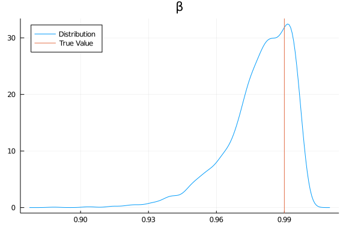

```julia
using JLD, StatsPlots

results = load("/home/danielc/Documentos/dsge-hmc_V2/values.jld")
tab = results["samples"]

bet = 0.99
sig = 1
phi = 1
alfa = 1/3
epsilon = 6
theta = 2/3
phi_pi = 1.5
phi_y = 0.5/4
rho_v = 0.5
s2 = 1

to_unit(x) = 1/(1+exp(-x))
to_positive(x) = exp(x)
to_one_inf(x) = exp(x) + 1

true_pars = [alfa,bet,epsilon,theta, sig, s2, phi,phi_pi, phi_y,rho_v]

StatsPlots.density(to_unit.(tab[1:2000,1]), legend = :topleft, label = "Distribution", title = "β")
vline!([true_pars[2]],label = "True Value")
```

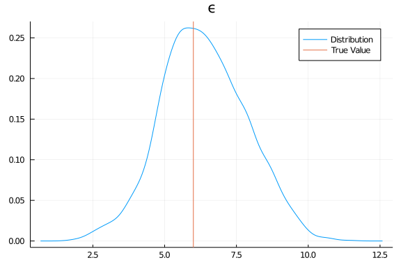

```julia
StatsPlots.density(to_positive.(tab[1:2000,2]), label = "Distribution",title = "ϵ")
vline!([true_pars[3]],label = "True Value")
```

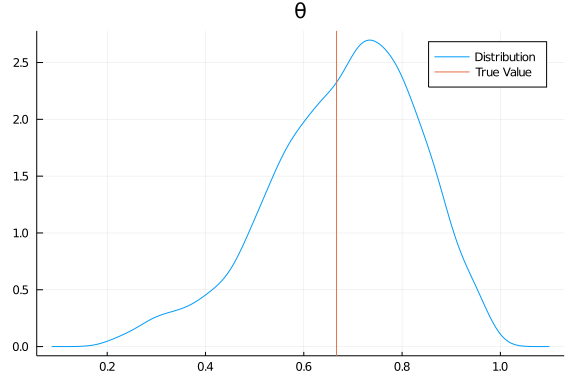

```julia
StatsPlots.density(to_unit.(tab[1:2000,3]), label = "Distribution", title = "θ")
vline!([true_pars[4]],label = "True Value")
```

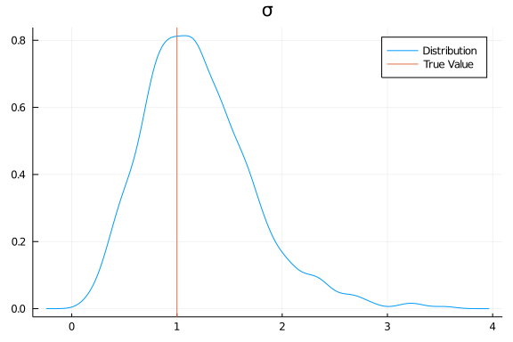

```julia
StatsPlots.density(to_positive.(tab[1:2000,4]), label = "Distribution",title = "σ")
vline!([true_pars[5]],label = "True Value")
```

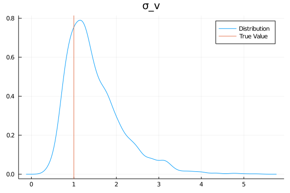

```julia
StatsPlots.density(to_positive.(tab[1:2000,5]), label = "Distribution", title = "σ_v")
vline!([true_pars[6]],label = "True Value")
```

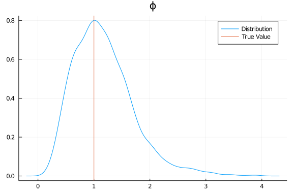

```julia
StatsPlots.density(to_positive.(tab[1:2000,6]), label = "Distribution",title = "ϕ")
vline!([true_pars[7]],label = "True Value")
```

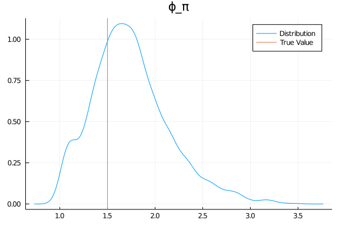

```julia
StatsPlots.density(to_one_inf.(tab[1:2000,7]), label = "Distribution", title = "ϕ_π")
vline!([true_pars[8]],label = "True Value")
```

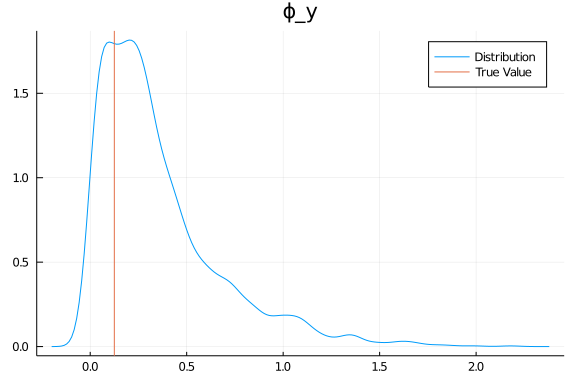

```julia
StatsPlots.density(to_positive.(tab[1:2000,8]), label = "Distribution", title = "ϕ_y")
vline!([true_pars[9]],label = "True Value")
```

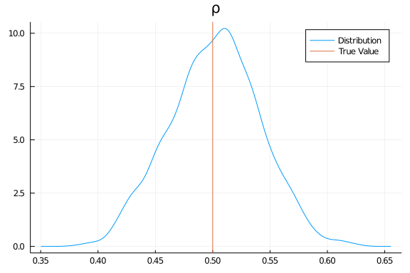

```julia
StatsPlots.density(to_unit.(tab[1:2000,9]), label = "Distribution", title = "ρ")
vline!([true_pars[10]],label = "True Value")
```

Unfortunately, due to the fact that each iteration requires a number of calls of the function to generate the next sample, the process is slow: it took almost 8 hours in an i5-3210M and 6GB of RAM. The good news is that it scales better than RWMH for large parameter space so for large models the estimation the price of evaluating the function and the derivative for 10 parameters is not much smaller than the price for larger parameters.

# Appendix I: Derivates for the Kalman Filter

Lets repeat the space state structure:

$$y_t = Gx_t + u_t\\
x_{t+1} = Ax_t + v_t$$

And recall that $u_t \sim N(0,R)$ and $v_t \sim N(0,Q)$. The equations used in the Kalman Filter are listed bellow:

$$\eta_t = y_t -G\hat{x}_{t|t-1} \quad (i) \\
B_t = GP_{t|t-1}G^{\prime} + R \quad (ii) \\
K_t = AP_{t|t-1}G^{\prime}B_t^{-1} \quad (iii) \\
P_{t+1|t} = AP_{t|t-1}A^{\prime} - K_tB_tK_t^{\prime} + Q \quad (iv)\\
\hat{x}_{t+1|t} = A\hat{x}_{t|t-1} + K_t\eta_t \quad (v)\\$$

Equation (i) is the error from observing the data now based on the state updated to the last data. Equation (ii) is the error of the observables. Equation (iii) is the Kalman gain. Equation (iv) is the variance of the state tomorrow conditional on the data from today. Equation (v) tells us how we update the state to incorporate the dynamic and the new information from the state.

We clearly need $d\eta_t/d\theta$ and $dB_t/d\theta$, which show up in the loglikelihood. For the rest of this appendix we will drop the $d\theta$ on the denominator. We will use the vec trick:

$$vec(ABC) = (C^{\prime} \otimes A) vec(B)$$

And $\otimes$ is the kronecker product. Then, lets differentiate in order. I will use the vec trick and the fact that neither $G$ nor $R$ depends on the parameter vector for most models. I will just use $\nabla$ when we have a gradient. Then we have, for (i):

$$\nabla \eta_t = -G d\hat{x}_{t|t-1}$$

Now for (ii):

$$dB_t = GdP_{t|t-1}G^{\prime}\\
dvec(B_t) = (G \otimes G) dvec(P_{t|t-1})$$

Now equation (iii):

$$dK_t = dAP_{t|t-1}G^{\prime} + AdP_{t|t-1}G^{\prime} + dR\\
dvec(K_t) = (GP_{t|t-1} \otimes I) dvec(A) + (G \otimes A) dvec(P_{t|t-1}) + dvec(R)$$

Now equation (iv):

$$dP_{t+1|t} = dAP_{t|t-1}A^{\prime} + AdP_{t|t-1}A^{\prime} + AP_{t|t-1}dA^{\prime} - dK_tB_tK_t^{\prime} + \\ - K_tdB_tK_t^{\prime} - K_tB_tdK_t^{\prime} + dQ\\
dvec(P_{t+1|t}) = (AP_{t|t-1}\otimes I) dvec(A) + (A \otimes A) dvec(P_{t|t-1}) + \\ + (I \otimes AP_{t|t-1}) dvec(A^{\prime}) - (K_t B_t \otimes I) dvec(K_t) - (K_t \otimes K_t) dvec(B_t) - (I \otimes K_t B_t) dvec(K_t^{\prime}) + dvec(Q)$$

Finally, equation (v):

$$d\hat{x}_{t+1|t} = dA \hat{x}_{t|t-1} + A d\hat{x}_{t|t-1} + dK_t \eta_t + K_t d\eta_t \\
d\hat{x}_{t+1|t} = (\hat{x}_{t|t-1}^{\prime} \otimes I)dvec(A) + Ad\hat{x}_{t|t-1} + (\eta_t^{\prime} \otimes I) dvec(K_t) + K_t d\eta_t\\$$

Notice that we need the previous value of the derivative for the derivative of equations (iv) and (v).

# Appendix II: file structure

Folders:

- Imgs: Alll images are saved here
- Reports: All reports are saved here
- old: From the previous attempts at this

Files:

Main files:

- HMC.jl: The main file for estimation, depends on every other file on the folder
- renormalization_manual.jl: Reparametrization of the posterior so the parameters belong to the whole real line
- llh_diff.jl: The loglikelihood and its derivative
- priors.jl: The priors for all parameters
- diff_kalman.jl: The functions that calculate the derivative of the Kalman Filter. It defines a structure to hold what the Kalman filter needs in terms of derivative and functions to compute each derivative that is needed.
- diffs_estrut_v3.jl: DIfferentiates the structural model, based on Iskrev (2007). It also holds the matrices needed for the model, which is not a good pratice but is not hard to change it.
- gensys.jl: Our implementation of gensys, described in Sims (2002)
- aux_matrix.jl: Implementations of duplication and commutation matrices
- simulation.jl: Uses gensys and an input model to generate data from that model.

Tests files:

- test.jl: Tests most of the functions to make sure there are no bugs on them and they return reasonable values
- diff_tests.jl: Extensive test of the analytical derivatives, compared against finite difference derivative. They do not need to be equal, but should be “close”

Auxiliar files:

- galis_example.jl and gali_bayesian.jl: Sets up the matrices for Gali (2008) model example and the parameter values, as well as the guess and verify solutions available in the book so we can compare the IRFs with the IRF from gensys
- autocorrelation.jl: Cheap and quick implementation of a function to calculate autocorrelation

Data cleaning:

- tests_pos_mcmc.jl: Just calculates the autocorrelation and the effective sample size for now, in the future will include more assesments of the simulation.

# Bibliography

Anderson, Gary, and George Moore. 1985. “A linear algebraic procedure for solving linear perfect foresight models.” *Economics Letters*. https://doi.org/10.1016/0165-1765(85)90211-3.

Betancourt, Michael. 2017. “A Conceptual Introduction to Hamiltonian Monte Carlo.” http://arxiv.org/abs/1701.02434.

Blanchard, Olivier Jean, and Charles M. Kahn. 1980. “The Solution of Linear Difference Models under Rational Expectations.” *Econometrica*. https://doi.org/10.2307/1912186.

Fernández-Villaverde, Jesús, and Pablo A Guerrón-Quintana. 2020. “Estimating Dsge Models: Recent Advances and Future Challenges.” Working Paper 27715. Working Paper Series. National Bureau of Economic Research. https://doi.org/10.3386/w27715.

Galí, Jordi. 2009. *Monetary policy, inflation, and the business cycle: An introduction to the new Keynesian framework*. https://doi.org/10.1111/j.1475-4932.2009.00606.x.

Gelman, Andrew, John B B Carlin, Hal S S Stern, and Donald B B Rubin. 2014. *Bayesian Data Analysis, Third Edition (Texts in Statistical Science)*. https://doi.org/10.1007/s13398-014-0173-7.2.

Iskrev, Nikolay. 2010. “Local identification in DSGE models.” *Journal of Monetary Economics*. https://doi.org/10.1016/j.jmoneco.2009.12.007.

Magnus, Jan R, and Heinz Neudecker. 2019. *Matrix Differential Calculus with Applications in Statistics and Econometrics*. John Wiley & Sons.

Neal, Radford M. 2011. “MCMC using hamiltonian dynamics.” In *Handbook of Markov Chain Monte Carlo*. https://doi.org/10.1201/b10905-6.

Sims, Christopher A. 2002. “Solving Linear Rational Expectations Models.” *Computational Economics*. https://doi.org/10.1023/A:1020517101123.

[^1]: By analytically I mean not using finite differences or automatic differentiation. Since we depend on a large number of kronecker products, we implement the derivative as functions in Julia
[^2]: Which depends on time since it depends on the estimated state, that depends on time.
[^3]: For now

Published from using Weave.jl v0.10.6 on 2021-01-02.